# COPYAS2

Dans Lismanis

2023-10-08

## Questions 2,3

```r
df=read.csv("oj.csv")
library(ggplot2)
```

## Question 4

### a)

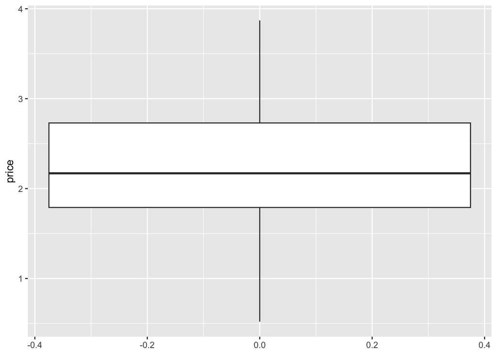

```r
ggplot(df, aes(y = price)) + geom_boxplot()
```

### b)

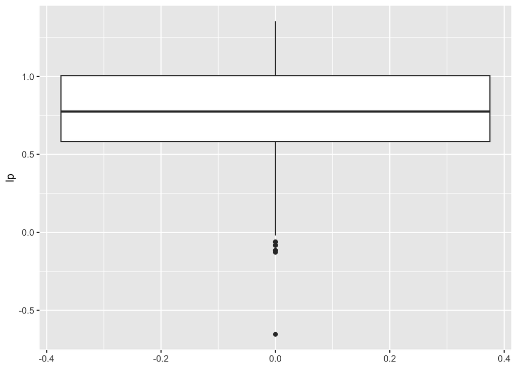

```r
lp=log(df$price)
ggplot(df, aes(y = lp)) + geom_boxplot()
```

### c)

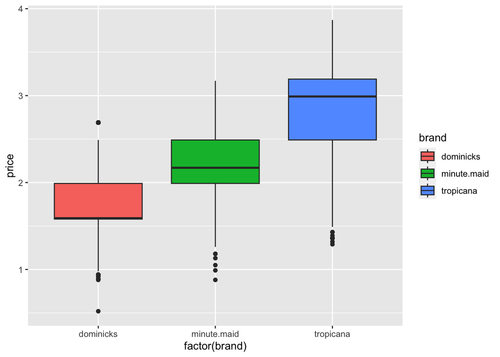

```r
ggplot(df,aes(factor(brand), price)) + geom_boxplot(aes(fill=brand))
```

### d)

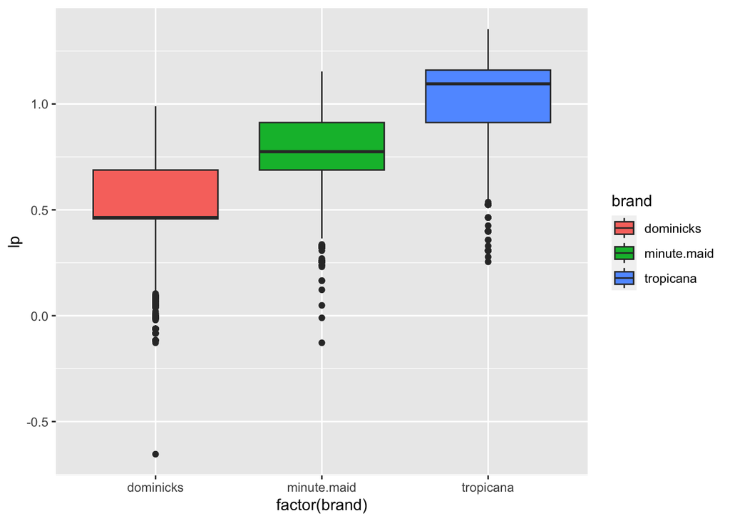

```r
ggplot(df,aes(factor(brand), lp)) + geom_boxplot(aes(fill=brand))
```

## Question 5

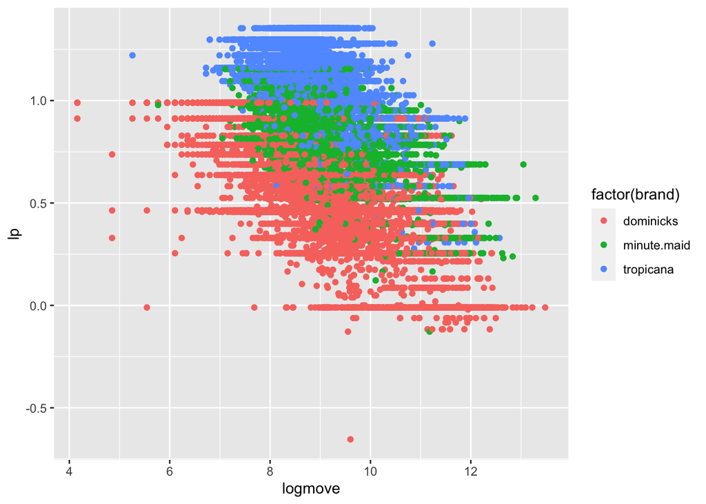

```r
ggplot(df,aes(logmove, lp)) + geom_point(aes(color=factor(brand)))
```

## a)

Here we can see all the sales of different brands at different price points. We can also use this to estimate the elasticities of the different brands.

## Question 6

### a)

```r
reg1=lm(logmove ~ lp, data=df)
summary(reg1)
```

```
##
## Call:
## lm(formula = logmove ~ lp, data = df)
##
## Residuals:
##     Min      1Q  Median      3Q     Max
## -5.0441 -0.5853 -0.0330  0.5756  3.7264
##
## Coefficients:
##             Estimate Std. Error t value Pr(>|t|)
## (Intercept) 10.42342    0.01535  679.04   <2e-16 ***
## lp          -1.60131    0.01836  -87.22   <2e-16 ***
## ---
## Signif. codes:  0 '***' 0.001 '**' 0.01 '*' 0.05 '.' 0.1 ' ' 1
##
## Residual standard error: 0.9071 on 28945 degrees of freedom
## Multiple R-squared:  0.2081, Adjusted R-squared:  0.2081
## F-statistic:  7608 on 1 and 28945 DF,  p-value: < 2.2e-16
```

```r
pred=predict(reg1)
residual=df$logmove-pred
mse=mean(residual^2)
mse
```

```
## [1] 0.8228178
```

```r
MeanP=mean(df$price)
MeanQ=mean(exp(df$logmove))
Elasticity=(MeanP/MeanQ)*(-1.60131)
Elasticity
```

```
## [1] -0.0002111209
```

To evaluate the model fit we look at the MSE which is 0.8228178. Furthermore we can see that R^2 of this model is 0.2081. The elasticity of this model is -0.0002111209, this makes sense as we are looking at the elasticity of the orange juice as whole, and people who really like orange juice will keep buying it even if the price increases.

### b)

```r
reg2=lm(logmove ~ lp + brand, data=df)
summary(reg2)
```

```
##
## Call:
## lm(formula = logmove ~ lp + brand, data = df)
##
## Residuals:
##     Min      1Q  Median      3Q     Max
## -5.3152 -0.5246 -0.0502  0.4929  3.5088
##
## Coefficients:
##                  Estimate Std. Error t value Pr(>|t|)
## (Intercept)      10.82882    0.01453  745.04   <2e-16 ***
## lp               -3.13869    0.02293 -136.89   <2e-16 ***
## brandminute.maid  0.87017    0.01293   67.32   <2e-16 ***
## brandtropicana    1.52994    0.01631   93.81   <2e-16 ***
## ---
## Signif. codes:  0 '***' 0.001 '**' 0.01 '*' 0.05 '.' 0.1 ' ' 1
##
## Residual standard error: 0.7935 on 28943 degrees of freedom
## Multiple R-squared:  0.3941, Adjusted R-squared:  0.394
## F-statistic:  6275 on 3 and 28943 DF,  p-value: < 2.2e-16
```

The coefficient of logarithm m of price (lp) went from -1.6 to -3.1, this is due to the fact that we have now included dummy variables for both minute maid and tropicana. This increase in predicted coefficient of lp makes sense as Dominics orange juice is bound to bee more elastic.

Interpreting the coefficient of lp:

Increasing the price of orange juice by 1%, ceteris paribus, will decrease the quantity of orange juice sold by 3.1%.

Interpreting just the dummy variables:

1)If the brand of orange juice is changed from dominics to Minute maid, ceteris paribus, then the the log quantity sold will increase by 0.87. So the quantity sold will increase by 139%.

### c)

```r
library(fastDummies)
df=dummy_cols(df, select_columns ='brand')
df$dom_lp=lp*df$brand_dominicks
df$min_lp=lp*df$brand_minute.maid
df$tro_lp=lp*df$brand_tropicana
reg3=lm(logmove ~ dom_lp+min_lp + tro_lp,data=df)
summary(reg3)
```

```
##
## Call:
## lm(formula = logmove ~ dom_lp + min_lp + tro_lp, data = df)
##
## Residuals:
##     Min      1Q  Median      3Q     Max
## -5.7859 -0.5188 -0.0570  0.4840  3.5856
##
## Coefficients:
##             Estimate Std. Error t value Pr(>|t|)
## (Intercept) 11.29172    0.01668   676.8   <2e-16 ***
## dom_lp      -3.92032    0.03042  -128.9   <2e-16 ***
## min_lp      -2.65843    0.02243  -118.5   <2e-16 ***
## tro_lp      -2.13001    0.01734  -122.8   <2e-16 ***
## ---
## Signif. codes:  0 '***' 0.001 '**' 0.01 '*' 0.05 '.' 0.1 ' ' 1
##
## Residual standard error: 0.801 on 28943 degrees of freedom
## Multiple R-squared:  0.3827, Adjusted R-squared:  0.3826
## F-statistic:  5981 on 3 and 28943 DF,  p-value: < 2.2e-16
```

```r
DomElast=MeanP/MeanQ* -3.92032
MinElast=MeanP/MeanQ*-2.65843
TroElast=MeanP/MeanQ*-2.13001
DomElast
```

```
## [1] -0.0005168654
```

```r
MinElast
```

```
## [1] -0.0003504944
```

```r
TroElast
```

```
## [1] -0.0002808262
```

We can see how much does a price change impacts the ln of quantity sold for each firm.  
The elasticity for firm Dominicks is -0.0005168654, for Minute maid is -0.0003504944 and for Tropicana -0.0002808262.  
These elasticities make sense as the more expensive brand is the lower the elasticity is.

## Question 7

### a)

```r
library(dplyr)
df_group= df %>%
  group_by(brand)
df_summary= df_group %>%
  summarize(meanprice=mean(price),featrate=mean(feat),meanmove=mean(logmove))
df_summary
```

```
## # A tibble: 3 × 4
##   brand       meanprice featrate meanmove
##   <chr>           <dbl>    <dbl>    <dbl>
## 1 dominicks        1.74    0.257     9.17
## 2 minute.maid      2.24    0.289     9.22
## 3 tropicana        2.87    0.166     9.11
```

### b)

We add a dummy variable for the linear regression to indicate wheather this product was featured or not $\beta_{feat}$ now $y_i=\beta_0 + \beta_{dom\_lp}dom\_lp_i+\beta_{min\_lp}min\_lp_i +\beta_{tro\_lp}tro\_lp_i+\beta_{feat}feat_i+\epsilon_i$

### c)

```r
reg7c=lm(logmove ~ dom_lp+min_lp + tro_lp+ feat,data=df)
summary(reg7c)
```

```
##
## Call:
## lm(formula = logmove ~ dom_lp + min_lp + tro_lp + feat, data = df)
##
## Residuals:
##     Min      1Q  Median      3Q     Max
## -5.1441 -0.4393 -0.0065  0.4215  3.2097
##
## Coefficients:
##             Estimate Std. Error t value Pr(>|t|)
## (Intercept) 10.65705    0.01643  648.66   <2e-16 ***
## dom_lp      -3.20468    0.02815 -113.86   <2e-16 ***
## min_lp      -2.17657    0.02061 -105.61   <2e-16 ***
## tro_lp      -1.65726    0.01627 -101.86   <2e-16 ***
## feat         0.92273    0.01039   88.78   <2e-16 ***
## ---
## Signif. codes:  0 '***' 0.001 '**' 0.01 '*' 0.05 '.' 0.1 ' ' 1
##
## Residual standard error: 0.7101 on 28942 degrees of freedom
## Multiple R-squared:  0.5148, Adjusted R-squared:  0.5147
## F-statistic:  7677 on 4 and 28942 DF,  p-value: < 2.2e-16
```

### d)

```r
df=dummy_cols(df, select_columns ='brand')
df$featdom=df$feat*df$brand_dominicks
df$featminu=df$feat*df$brand_minute.maid
df$feattro=df$feat*df$brand_tropicana

reg7c=lm(logmove~ dom_lp+min_lp+tro_lp+featdom+featminu+feattro, data=df)
summary(reg7c)
```

```
##
## Call:
## lm(formula = logmove ~ dom_lp + min_lp + tro_lp + featdom + featminu +
##     feattro, data = df)
##
## Residuals:
##     Min      1Q  Median      3Q     Max
## -5.1676 -0.4330 -0.0035  0.4192  3.1851
##
## Coefficients:
##             Estimate Std. Error t value Pr(>|t|)
## (Intercept) 10.68054    0.01647  648.50   <2e-16 ***
## dom_lp      -3.20262    0.02799 -114.42   <2e-16 ***
## min_lp      -2.27032    0.02122 -106.98   <2e-16 ***
## tro_lp      -1.65643    0.01650 -100.40   <2e-16 ***
## featdom      0.80265    0.01646   48.75   <2e-16 ***
## featminu     1.13811    0.01546   73.64   <2e-16 ***
## feattro      0.74484    0.01905   39.09   <2e-16 ***
## ---
## Signif. codes:  0 '***' 0.001 '**' 0.01 '*' 0.05 '.' 0.1 ' ' 1
##
## Residual standard error: 0.7058 on 28940 degrees of freedom
## Multiple R-squared:  0.5207, Adjusted R-squared:  0.5206
## F-statistic:  5240 on 6 and 28940 DF,  p-value: < 2.2e-16
```

```r
ElastDom=1.74/9.17*-3.20262
ElastDom
```

```
## [1] -0.6076945
```

```r
ElastMinuteMaid=2.24/9.22*-2.27032
ElastMinuteMaid
```

```
## [1] -0.5515745
```

```r
ElastTrop=2.87/9.11*-1.65643
ElastTrop
```

```
## [1] -0.5218391
```

### e)

```r
reg7e=lm(logmove~ dom_lp+min_lp+tro_lp+featdom+featminu+feattro+EDUC+ETHNIC+HVAL150, data=df)
summary(reg7e)
```

```
##
## Call:
## lm(formula = logmove ~ dom_lp + min_lp + tro_lp + featdom + featminu +
##     feattro + EDUC + ETHNIC + HVAL150, data = df)
##
## Residuals:
##     Min      1Q  Median      3Q     Max
## -5.2673 -0.4243 -0.0011  0.4068  3.1516
##
## Coefficients:
##             Estimate Std. Error t value Pr(>|t|)
## (Intercept) 10.57605    0.01912  553.12   <2e-16 ***
## dom_lp      -3.28428    0.02763 -118.85   <2e-16 ***
## min_lp      -2.33085    0.02095 -111.27   <2e-16 ***
## tro_lp      -1.70320    0.01628 -104.60   <2e-16 ***
## featdom      0.78860    0.01619   48.72   <2e-16 ***
## featminu     1.13125    0.01519   74.47   <2e-16 ***
## feattro      0.73496    0.01873   39.24   <2e-16 ***
## EDUC        -1.08873    0.08070  -13.49   <2e-16 ***
## ETHNIC       0.67515    0.02410   28.01   <2e-16 ***
## HVAL150      0.85382    0.03856   22.14   <2e-16 ***
## ---
## Signif. codes:  0 '***' 0.001 '**' 0.01 '*' 0.05 '.' 0.1 ' ' 1
##
## Residual standard error: 0.6937 on 28937 degrees of freedom
## Multiple R-squared:  0.5371, Adjusted R-squared:  0.537
## F-statistic:  3731 on 9 and 28937 DF,  p-value: < 2.2e-16
```

## Question 8

### a)

From question 7d it can be seen that Dominicks has the highest demand elasticity and Tropicana has the lowest.

### b)

Yes, the average prices match with this result as Dominicks has the lowest average price and Tropicana highest.

```r
ChQSD=ElastDom*-1.65643
ChQSM=-3.20262*ElastMinuteMaid
ChQST=-2.27032*ElastTrop
UnitCostDom=1.74/(1+ChQSD)
UnitCostDom
```

```
## [1] 0.867137
```

```r
UnitCostMinuteMaid=2.24/(1+ChQSM)
UnitCostMinuteMaid
```

```
## [1] 0.8096922
```

```r
UnitCostTrop=2.87/(1+ChQST)
UnitCostTrop
```

```
## [1] 1.313656
```

```r
ProfDom=1.74-UnitCostDom
ProfMin=2.24-UnitCostMinuteMaid
ProfTrop=2.87-UnitCostTrop
ProfDom
```

```
## [1] 0.872863
```

```r
ProfMin
```

```
## [1] 1.430308
```

```r
ProfTrop
```

```
## [1] 1.556344
```

For Dominicks and Minute Maid unit costs are quite simillar, although, suprisingly Minute Maid has a lower unit cost and has a much higher average price. But still Tropicana makes the most profit per unit sold.

## Question 9

### a)

```r
reg9a=lm(logmove~ dom_lp+min_lp+tro_lp+featdom+featminu+feattro+AGE60+EDUC+ETHNIC+INCOME+HHLARGE+WORKWOM+HVAL150, data=df)
summary(reg9a)
```

```
##
## Call:
## lm(formula = logmove ~ dom_lp + min_lp + tro_lp + featdom + featminu +
##     feattro + AGE60 + EDUC + ETHNIC + INCOME + HHLARGE + WORKWOM +
##     HVAL150, data = df)
##
## Residuals:
##     Min      1Q  Median      3Q     Max
## -5.3436 -0.4044  0.0035  0.4019  3.0209
##
## Coefficients:
##             Estimate Std. Error  t value Pr(>|t|)
## (Intercept) 12.25036    0.31569   38.805  < 2e-16 ***
## dom_lp      -3.33228    0.02712 -122.860  < 2e-16 ***
## min_lp      -2.36653    0.02056 -115.109  < 2e-16 ***
## tro_lp      -1.73105    0.01598 -108.316  < 2e-16 ***
## featdom      0.77982    0.01586   49.179  < 2e-16 ***
## featminu     1.12669    0.01488   75.725  < 2e-16 ***
## feattro      0.72941    0.01834   39.764  < 2e-16 ***
## AGE60        1.49973    0.12780   11.735  < 2e-16 ***
## EDUC         0.47215    0.10092    4.679 2.90e-06 ***
## ETHNIC       0.57968    0.03640   15.925  < 2e-16 ***
## INCOME      -0.13735    0.03162   -4.344 1.40e-05 ***
## HHLARGE     -1.22207    0.23557   -5.188 2.14e-07 ***
## WORKWOM     -1.34759    0.14407   -9.354  < 2e-16 ***
## HVAL150      0.39359    0.04062    9.690  < 2e-16 ***
## ---
## Signif. codes:  0 '***' 0.001 '**' 0.01 '*' 0.05 '.' 0.1 ' ' 1
##
## Residual standard error: 0.6794 on 28933 degrees of freedom
## Multiple R-squared:  0.5561, Adjusted R-squared:  0.5559
## F-statistic:  2788 on 13 and 28933 DF,  p-value: < 2.2e-16
```

### b)

From the summary above we can see that all the added demographics variables are significant in determining the demand.

### c)

```r
reg9a=lm(logmove~ dom_lp+min_lp+tro_lp+featdom+featminu+feattro+AGE60+EDUC+ETHNIC+INCOME+HHLARGE+WORKWOM+HVAL150, data=df)
df$logmove_hat=predict(reg9a, newdata=df)
Rsq=cor(df$logmove,df$logmove_hat)
Rsq
```

```
## [1] 0.7456898
```

```r
##Now for no demographic data
reg7c=lm(logmove~ dom_lp+min_lp+tro_lp+featdom+featminu+feattro, data=df)
df$nodemolog=predict(reg7c, newdata=df)
Rsq7c=cor(df$logmove,df$nodemolog)
Rsq-Rsq7c
```

```
## [1] 0.02410366
```

### d)

```r
library(dplyr)
training=sample_n(df,size=28947*0.8)
test=anti_join(df,training)
```

[output not shown]

```r
nodomtrain=lm(logmove~ dom_lp+min_lp+tro_lp+featdom+featminu+feattro, data=training)
prednodomtrain=predict(nodomtrain)
MSE_nodomtrain=mean((training$logmove-prednodomtrain)^2)
MSE_nodomtrain
```

```
## [1] 0.4933219
```

```r
domtrain=lm(logmove~ dom_lp+min_lp+tro_lp+featdom+featminu+feattro+AGE60+EDUC+ETHNIC+INCOME+HHLARGE+WORKWOM+HVAL150, data=training)
preddomtrain=predict(domtrain)
MSE_domtrain=mean((training$logmove-preddomtrain)^2)
MSE_domtrain
```

```
## [1] 0.4586242
```

```r
nodomtest=lm(logmove~ dom_lp+min_lp+tro_lp+featdom+featminu+feattro, data=test)
prednodomtest=predict(nodomtest)
MSE_nodomtest=mean((test$logmove-prednodomtest)^2)
MSE_nodomtest
```

```
## [1] 0.516762
```

```r
domtest=lm(logmove~ dom_lp+min_lp+tro_lp+featdom+featminu+feattro+AGE60+EDUC+ETHNIC+INCOME+HHLARGE+WORKWOM+HVAL150, data=test)
MSE_domtest=mean((test$logmove-(predict(domtest)))^2)
MSE_domtest
```

```
## [1] 0.4707843
```

With both the sampeling and testing data the regression with the domestic variables included has the lower MSE, thereby implying that it is the preffered model.